# Risk Factor Analysis

## Outcome Variable

**Outcome Variable:** stunted

## Predictor Variables

**Intervention Variable:** exclfeed6

**Adjustment Set:**

- arm
- sex
- brthmon
- W_mage
- meducyrs
- feducyrs
- hhwealth_quart
- hfoodsec
- W_mhtcm
- W_mwtkg
- W_mbmi
- vagbrth
- W_gagebrth
- W_birthwt
- W_birthlen
- W_nrooms
- W_nchldlt5
- month
- W_parity
- impfloor
- impsan
- safeh20
- delta_W_mage
- delta_meducyrs
- delta_feducyrs
- delta_hhwealth_quart
- delta_hfoodsec
- delta_W_mhtcm
- delta_W_mwtkg
- delta_W_mbmi
- delta_vagbrth
- delta_W_gagebrth
- delta_W_birthwt
- delta_W_birthlen
- delta_W_nrooms
- delta_W_nchldlt5
- delta_month
- delta_W_parity
- delta_impfloor
- delta_impsan
- delta_safeh20

## Stratifying Variables

The analysis was stratified on these variable(s):

- agecat
- studyid
- country

## Data Summary

| agecat | studyid | country | exclfeed6 | stunted | n_cell | n |
| --- | --- | --- | --- | --- | --- | --- |
| Birth | ki0047075b-MAL-ED | BANGLADESH | 1 | 0 | 26 | 205 |
| Birth | ki0047075b-MAL-ED | BANGLADESH | 1 | 1 | 5 | 205 |
| Birth | ki0047075b-MAL-ED | BANGLADESH | 0 | 0 | 143 | 205 |
| Birth | ki0047075b-MAL-ED | BANGLADESH | 0 | 1 | 31 | 205 |
| Birth | ki0047075b-MAL-ED | BRAZIL | 1 | 0 | 0 | 60 |
| Birth | ki0047075b-MAL-ED | BRAZIL | 1 | 1 | 2 | 60 |
| Birth | ki0047075b-MAL-ED | BRAZIL | 0 | 0 | 51 | 60 |
| Birth | ki0047075b-MAL-ED | BRAZIL | 0 | 1 | 7 | 60 |
| Birth | ki0047075b-MAL-ED | INDIA | 1 | 0 | 0 | 39 |
| Birth | ki0047075b-MAL-ED | INDIA | 1 | 1 | 1 | 39 |
| Birth | ki0047075b-MAL-ED | INDIA | 0 | 0 | 31 | 39 |
| Birth | ki0047075b-MAL-ED | INDIA | 0 | 1 | 7 | 39 |
| Birth | ki0047075b-MAL-ED | NEPAL | 1 | 0 | 2 | 24 |
| Birth | ki0047075b-MAL-ED | NEPAL | 1 | 1 | 0 | 24 |
| Birth | ki0047075b-MAL-ED | NEPAL | 0 | 0 | 21 | 24 |
| Birth | ki0047075b-MAL-ED | NEPAL | 0 | 1 | 1 | 24 |
| Birth | ki0047075b-MAL-ED | PERU | 1 | 0 | 2 | 213 |
| Birth | ki0047075b-MAL-ED | PERU | 1 | 1 | 0 | 213 |
| Birth | ki0047075b-MAL-ED | PERU | 0 | 0 | 185 | 213 |
| Birth | ki0047075b-MAL-ED | PERU | 0 | 1 | 26 | 213 |
| Birth | ki0047075b-MAL-ED | SOUTH AFRICA | 1 | 0 | 0 | 91 |
| Birth | ki0047075b-MAL-ED | SOUTH AFRICA | 1 | 1 | 0 | 91 |
| Birth | ki0047075b-MAL-ED | SOUTH AFRICA | 0 | 0 | 83 | 91 |
| Birth | ki0047075b-MAL-ED | SOUTH AFRICA | 0 | 1 | 8 | 91 |
| Birth | ki0047075b-MAL-ED | TANZANIA, UNITED REPUBLIC OF | 1 | 0 | 0 | 113 |
| Birth | ki0047075b-MAL-ED | TANZANIA, UNITED REPUBLIC OF | 1 | 1 | 0 | 113 |
| Birth | ki0047075b-MAL-ED | TANZANIA, UNITED REPUBLIC OF | 0 | 0 | 92 | 113 |
| Birth | ki0047075b-MAL-ED | TANZANIA, UNITED REPUBLIC OF | 0 | 1 | 21 | 113 |
| Birth | ki1000108-CMC-V-BCS-2002 | INDIA | 1 | 0 | 7 | 7 |
| Birth | ki1000108-CMC-V-BCS-2002 | INDIA | 1 | 1 | 0 | 7 |

[output cut: 170 more lines]

The following strata were considered:

- agecat: 24 months, studyid: ki0047075b-MAL-ED, country: BANGLADESH
- agecat: 24 months, studyid: ki0047075b-MAL-ED, country: BRAZIL
- agecat: 24 months, studyid: ki0047075b-MAL-ED, country: INDIA
- agecat: 24 months, studyid: ki0047075b-MAL-ED, country: NEPAL
- agecat: 24 months, studyid: ki0047075b-MAL-ED, country: PERU
- agecat: 24 months, studyid: ki0047075b-MAL-ED, country: SOUTH AFRICA
- agecat: 24 months, studyid: ki0047075b-MAL-ED, country: TANZANIA, UNITED REPUBLIC OF
- agecat: 24 months, studyid: ki1000108-CMC-V-BCS-2002, country: INDIA
- agecat: 24 months, studyid: ki1000108-IRC, country: INDIA
- agecat: 24 months, studyid: ki1000109-EE, country: PAKISTAN
- agecat: 24 months, studyid: ki1017093b-PROVIDE, country: BANGLADESH
- agecat: 24 months, studyid: ki1101329-Keneba, country: GAMBIA
- agecat: 24 months, studyid: ki1113344-GMS-Nepal, country: NEPAL
- agecat: 24 months, studyid: ki1148112-LCNI-5, country: MALAWI
- agecat: 24 months, studyid: kiGH5241-JiVitA-3, country: BANGLADESH
- agecat: 24 months, studyid: kiGH5241-JiVitA-4, country: BANGLADESH
- agecat: 6 months, studyid: ki0047075b-MAL-ED, country: BANGLADESH
- agecat: 6 months, studyid: ki0047075b-MAL-ED, country: BRAZIL
- agecat: 6 months, studyid: ki0047075b-MAL-ED, country: INDIA
- agecat: 6 months, studyid: ki0047075b-MAL-ED, country: NEPAL
- agecat: 6 months, studyid: ki0047075b-MAL-ED, country: PERU
- agecat: 6 months, studyid: ki0047075b-MAL-ED, country: SOUTH AFRICA
- agecat: 6 months, studyid: ki0047075b-MAL-ED, country: TANZANIA, UNITED REPUBLIC OF
- agecat: 6 months, studyid: ki1000108-CMC-V-BCS-2002, country: INDIA
- agecat: 6 months, studyid: ki1000108-IRC, country: INDIA
- agecat: 6 months, studyid: ki1000109-EE, country: PAKISTAN
- agecat: 6 months, studyid: ki1000304b-SAS-CompFeed, country: INDIA
- agecat: 6 months, studyid: ki1000304b-SAS-FoodSuppl, country: INDIA
- agecat: 6 months, studyid: ki1017093b-PROVIDE, country: BANGLADESH
- agecat: 6 months, studyid: ki1101329-Keneba, country: GAMBIA
- agecat: 6 months, studyid: ki1113344-GMS-Nepal, country: NEPAL
- agecat: 6 months, studyid: ki1148112-LCNI-5, country: MALAWI
- agecat: 6 months, studyid: kiGH5241-JiVitA-3, country: BANGLADESH
- agecat: 6 months, studyid: kiGH5241-JiVitA-4, country: BANGLADESH
- agecat: Birth, studyid: ki0047075b-MAL-ED, country: BANGLADESH
- agecat: Birth, studyid: ki0047075b-MAL-ED, country: BRAZIL
- agecat: Birth, studyid: ki0047075b-MAL-ED, country: INDIA
- agecat: Birth, studyid: ki0047075b-MAL-ED, country: NEPAL
- agecat: Birth, studyid: ki0047075b-MAL-ED, country: PERU
- agecat: Birth, studyid: ki0047075b-MAL-ED, country: SOUTH AFRICA
- agecat: Birth, studyid: ki0047075b-MAL-ED, country: TANZANIA, UNITED REPUBLIC OF
- agecat: Birth, studyid: ki1000108-CMC-V-BCS-2002, country: INDIA
- agecat: Birth, studyid: ki1000108-IRC, country: INDIA
- agecat: Birth, studyid: ki1000109-EE, country: PAKISTAN
- agecat: Birth, studyid: ki1000304b-SAS-CompFeed, country: INDIA
- agecat: Birth, studyid: ki1017093b-PROVIDE, country: BANGLADESH
- agecat: Birth, studyid: ki1101329-Keneba, country: GAMBIA
- agecat: Birth, studyid: ki1113344-GMS-Nepal, country: NEPAL
- agecat: Birth, studyid: kiGH5241-JiVitA-3, country: BANGLADESH
- agecat: Birth, studyid: kiGH5241-JiVitA-4, country: BANGLADESH

### Dropped Strata

Some strata were dropped due to rare outcomes:

- agecat: Birth, studyid: ki0047075b-MAL-ED, country: BRAZIL
- agecat: Birth, studyid: ki0047075b-MAL-ED, country: INDIA
- agecat: Birth, studyid: ki0047075b-MAL-ED, country: NEPAL
- agecat: Birth, studyid: ki0047075b-MAL-ED, country: PERU
- agecat: Birth, studyid: ki0047075b-MAL-ED, country: SOUTH AFRICA
- agecat: Birth, studyid: ki0047075b-MAL-ED, country: TANZANIA, UNITED REPUBLIC OF
- agecat: Birth, studyid: ki1000108-CMC-V-BCS-2002, country: INDIA
- agecat: Birth, studyid: ki1000108-IRC, country: INDIA
- agecat: Birth, studyid: ki1000109-EE, country: PAKISTAN
- agecat: 6 months, studyid: ki0047075b-MAL-ED, country: BRAZIL
- agecat: 6 months, studyid: ki0047075b-MAL-ED, country: INDIA
- agecat: 6 months, studyid: ki0047075b-MAL-ED, country: NEPAL
- agecat: 6 months, studyid: ki0047075b-MAL-ED, country: PERU
- agecat: 6 months, studyid: ki0047075b-MAL-ED, country: SOUTH AFRICA
- agecat: 6 months, studyid: ki0047075b-MAL-ED, country: TANZANIA, UNITED REPUBLIC OF
- agecat: 6 months, studyid: ki1000108-CMC-V-BCS-2002, country: INDIA
- agecat: 6 months, studyid: ki1000108-IRC, country: INDIA
- agecat: 6 months, studyid: ki1000109-EE, country: PAKISTAN
- agecat: 6 months, studyid: ki1000304b-SAS-FoodSuppl, country: INDIA
- agecat: 24 months, studyid: ki0047075b-MAL-ED, country: BRAZIL
- agecat: 24 months, studyid: ki0047075b-MAL-ED, country: INDIA
- agecat: 24 months, studyid: ki0047075b-MAL-ED, country: NEPAL
- agecat: 24 months, studyid: ki0047075b-MAL-ED, country: PERU
- agecat: 24 months, studyid: ki0047075b-MAL-ED, country: SOUTH AFRICA
- agecat: 24 months, studyid: ki0047075b-MAL-ED, country: TANZANIA, UNITED REPUBLIC OF
- agecat: 24 months, studyid: ki1000108-CMC-V-BCS-2002, country: INDIA
- agecat: 24 months, studyid: ki1000108-IRC, country: INDIA
- agecat: 24 months, studyid: ki1000109-EE, country: PAKISTAN

## Methods Detail

We’re interested in the causal parameters $E[Y_a]$ for all values of $a \in \mathcal{A}$. These parameters represent the mean outcome if, possibly contrary to fact, we intervened to set all units to have $A=a$. Under the randomization and positivity assumptions, these are identified by the statistical parameters $\psi_a=E_W[E_{Y|A,W}(Y|A=a,W)]$. In addition, we’re interested in the mean of $Y$, $E[Y]$ under no intervention (the observed mean). We will estimate these parameters by using SuperLearner to fit the relevant likelihood factors – $E_{Y|A,W}(Y|A=a,W)$ and $p(A=a|W)$, and then updating our likelihood fit using a joint TMLE.

For unadjusted analyses ($W=\{\}$), initial likelihoods were estimated using Lrnr_glm to estimate the simple $E(Y|A)$ and Lrnr_mean to estimate $p(A)$. For adjusted analyses, a small library containing Lrnr_glmnet, Lrnr_xgboost, and Lrnr_mean was used.

Having estimated these parameters, we will then use the delta method to estimate relative risks and attributable risks relative to a prespecified baseline level of $A$.

# Results Detail

## Results Plots

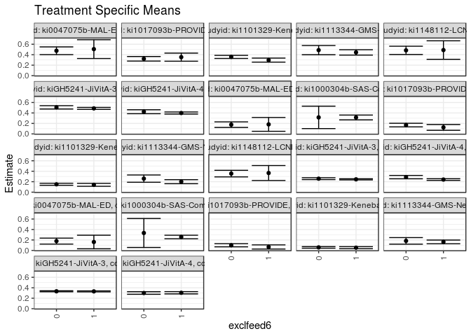

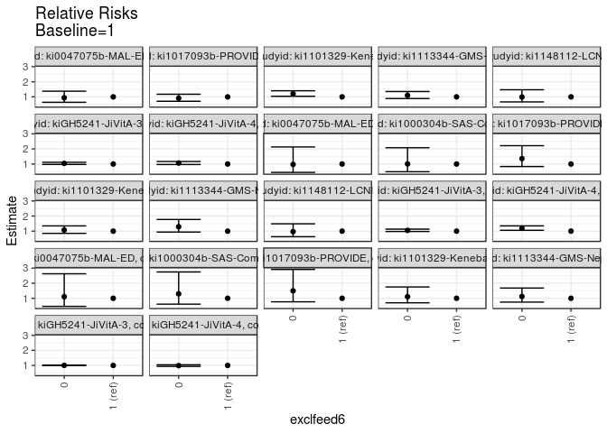

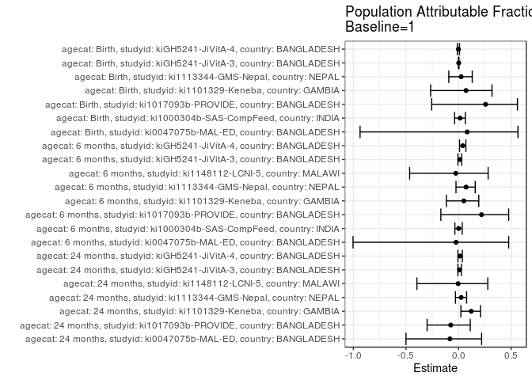

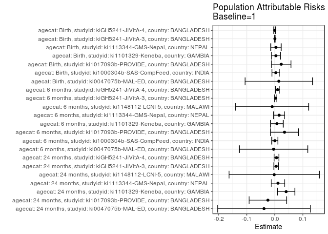

## Results Table

### Parameter: TSM

| agecat | studyid | country | intervention_level | baseline_level | estimate | ci_lower | ci_upper |
| --- | --- | --- | --- | --- | --- | --- | --- |
| Birth | ki0047075b-MAL-ED | BANGLADESH | 1 | NA | 0.1612903 | 0.0315010 | 0.2910797 |
| Birth | ki0047075b-MAL-ED | BANGLADESH | 0 | NA | 0.1781609 | 0.1211662 | 0.2351557 |
| Birth | ki1000304b-SAS-CompFeed | INDIA | 1 | NA | 0.2572254 | 0.2236819 | 0.2907690 |
| Birth | ki1000304b-SAS-CompFeed | INDIA | 0 | NA | 0.3333333 | 0.0564891 | 0.6101775 |
| Birth | ki1017093b-PROVIDE | BANGLADESH | 1 | NA | 0.0662390 | 0.0266129 | 0.1058651 |
| Birth | ki1017093b-PROVIDE | BANGLADESH | 0 | NA | 0.0989470 | 0.0689046 | 0.1289894 |
| Birth | ki1101329-Keneba | GAMBIA | 1 | NA | 0.0523232 | 0.0325826 | 0.0720639 |
| Birth | ki1101329-Keneba | GAMBIA | 0 | NA | 0.0579527 | 0.0428458 | 0.0730595 |
| Birth | ki1113344-GMS-Nepal | NEPAL | 1 | NA | 0.1628580 | 0.1274533 | 0.1982627 |
| Birth | ki1113344-GMS-Nepal | NEPAL | 0 | NA | 0.1823215 | 0.1197977 | 0.2448454 |
| Birth | kiGH5241-JiVitA-3 | BANGLADESH | 1 | NA | 0.3306967 | 0.3214440 | 0.3399495 |
| Birth | kiGH5241-JiVitA-3 | BANGLADESH | 0 | NA | 0.3325658 | 0.3227836 | 0.3423480 |
| Birth | kiGH5241-JiVitA-4 | BANGLADESH | 1 | NA | 0.3040265 | 0.2825062 | 0.3255467 |
| Birth | kiGH5241-JiVitA-4 | BANGLADESH | 0 | NA | 0.2999581 | 0.2755352 | 0.3243810 |
| 6 months | ki0047075b-MAL-ED | BANGLADESH | 1 | NA | 0.1818182 | 0.0499388 | 0.3136975 |
| 6 months | ki0047075b-MAL-ED | BANGLADESH | 0 | NA | 0.1767677 | 0.1235176 | 0.2300177 |
| 6 months | ki1000304b-SAS-CompFeed | INDIA | 1 | NA | 0.3139842 | 0.2679102 | 0.3600581 |
| 6 months | ki1000304b-SAS-CompFeed | INDIA | 0 | NA | 0.3157895 | 0.1014523 | 0.5301266 |
| 6 months | ki1017093b-PROVIDE | BANGLADESH | 1 | NA | 0.1243583 | 0.0690259 | 0.1796907 |
| 6 months | ki1017093b-PROVIDE | BANGLADESH | 0 | NA | 0.1688841 | 0.1347439 | 0.2030244 |
| 6 months | ki1101329-Keneba | GAMBIA | 1 | NA | 0.1403727 | 0.1129333 | 0.1678121 |
| 6 months | ki1101329-Keneba | GAMBIA | 0 | NA | 0.1505556 | 0.1315678 | 0.1695434 |
| 6 months | ki1113344-GMS-Nepal | NEPAL | 1 | NA | 0.2003566 | 0.1623256 | 0.2383875 |
| 6 months | ki1113344-GMS-Nepal | NEPAL | 0 | NA | 0.2587871 | 0.1890929 | 0.3284812 |
| 6 months | ki1148112-LCNI-5 | MALAWI | 1 | NA | 0.3660720 | 0.2233857 | 0.5087583 |
| 6 months | ki1148112-LCNI-5 | MALAWI | 0 | NA | 0.3546188 | 0.2918577 | 0.4173799 |
| 6 months | kiGH5241-JiVitA-3 | BANGLADESH | 1 | NA | 0.2453924 | 0.2344384 | 0.2563464 |
| 6 months | kiGH5241-JiVitA-3 | BANGLADESH | 0 | NA | 0.2580292 | 0.2402554 | 0.2758031 |
| 6 months | kiGH5241-JiVitA-4 | BANGLADESH | 1 | NA | 0.2411808 | 0.2251909 | 0.2571707 |
| 6 months | kiGH5241-JiVitA-4 | BANGLADESH | 0 | NA | 0.2877774 | 0.2558324 | 0.3197224 |
| 24 months | ki0047075b-MAL-ED | BANGLADESH | 1 | NA | 0.5068567 | 0.3276390 | 0.6860744 |
| 24 months | ki0047075b-MAL-ED | BANGLADESH | 0 | NA | 0.4753858 | 0.4015484 | 0.5492232 |
| 24 months | ki1017093b-PROVIDE | BANGLADESH | 1 | NA | 0.3533267 | 0.2761307 | 0.4305228 |
| 24 months | ki1017093b-PROVIDE | BANGLADESH | 0 | NA | 0.3218769 | 0.2783500 | 0.3654038 |
| 24 months | ki1101329-Keneba | GAMBIA | 1 | NA | 0.2966881 | 0.2582549 | 0.3351213 |
| 24 months | ki1101329-Keneba | GAMBIA | 0 | NA | 0.3581182 | 0.3287757 | 0.3874608 |
| 24 months | ki1113344-GMS-Nepal | NEPAL | 1 | NA | 0.4440590 | 0.3927987 | 0.4953193 |
| 24 months | ki1113344-GMS-Nepal | NEPAL | 0 | NA | 0.4874778 | 0.3995103 | 0.5754453 |
| 24 months | ki1148112-LCNI-5 | MALAWI | 1 | NA | 0.4888933 | 0.3120990 | 0.6656876 |
| 24 months | ki1148112-LCNI-5 | MALAWI | 0 | NA | 0.4830878 | 0.4038551 | 0.5623205 |
| 24 months | kiGH5241-JiVitA-3 | BANGLADESH | 1 | NA | 0.4874312 | 0.4687202 | 0.5061421 |
| 24 months | kiGH5241-JiVitA-3 | BANGLADESH | 0 | NA | 0.5074507 | 0.4757504 | 0.5391510 |
| 24 months | kiGH5241-JiVitA-4 | BANGLADESH | 1 | NA | 0.3990562 | 0.3794147 | 0.4186976 |
| 24 months | kiGH5241-JiVitA-4 | BANGLADESH | 0 | NA | 0.4236727 | 0.3860765 | 0.4612689 |

### Parameter: E(Y)

| agecat | studyid | country | intervention_level | baseline_level | estimate | ci_lower | ci_upper |
| --- | --- | --- | --- | --- | --- | --- | --- |
| Birth | ki0047075b-MAL-ED | BANGLADESH | NA | NA | 0.1756098 | 0.1233973 | 0.2278222 |
| Birth | ki1000304b-SAS-CompFeed | INDIA | NA | NA | 0.2609890 | 0.2179233 | 0.3040547 |
| Birth | ki1017093b-PROVIDE | BANGLADESH | NA | NA | 0.0890538 | 0.0649864 | 0.1131212 |
| Birth | ki1101329-Keneba | GAMBIA | NA | NA | 0.0563079 | 0.0442416 | 0.0683742 |
| Birth | ki1113344-GMS-Nepal | NEPAL | NA | NA | 0.1669627 | 0.1361293 | 0.1977961 |
| Birth | kiGH5241-JiVitA-3 | BANGLADESH | NA | NA | 0.3310735 | 0.3218922 | 0.3402548 |
| Birth | kiGH5241-JiVitA-4 | BANGLADESH | NA | NA | 0.3035714 | 0.2824097 | 0.3247332 |
| 6 months | ki0047075b-MAL-ED | BANGLADESH | NA | NA | 0.1774892 | 0.1281103 | 0.2268680 |
| 6 months | ki1000304b-SAS-CompFeed | INDIA | NA | NA | 0.3140704 | 0.2712850 | 0.3568557 |
| 6 months | ki1017093b-PROVIDE | BANGLADESH | NA | NA | 0.1589404 | 0.1297581 | 0.1881227 |
| 6 months | ki1101329-Keneba | GAMBIA | NA | NA | 0.1477987 | 0.1318701 | 0.1637274 |
| 6 months | ki1113344-GMS-Nepal | NEPAL | NA | NA | 0.2157221 | 0.1812209 | 0.2502233 |
| 6 months | ki1148112-LCNI-5 | MALAWI | NA | NA | 0.3566176 | 0.2995882 | 0.4136471 |
| 6 months | kiGH5241-JiVitA-3 | BANGLADESH | NA | NA | 0.2482578 | 0.2382387 | 0.2582768 |
| 6 months | kiGH5241-JiVitA-4 | BANGLADESH | NA | NA | 0.2511704 | 0.2362353 | 0.2661055 |
| 24 months | ki0047075b-MAL-ED | BANGLADESH | NA | NA | 0.4682927 | 0.3998183 | 0.5367670 |
| 24 months | ki1017093b-PROVIDE | BANGLADESH | NA | NA | 0.3287197 | 0.2903909 | 0.3670485 |
| 24 months | ki1101329-Keneba | GAMBIA | NA | NA | 0.3370787 | 0.3132517 | 0.3609056 |
| 24 months | ki1113344-GMS-Nepal | NEPAL | NA | NA | 0.4553191 | 0.4102488 | 0.5003895 |
| 24 months | ki1148112-LCNI-5 | MALAWI | NA | NA | 0.4867725 | 0.4153250 | 0.5582200 |
| 24 months | kiGH5241-JiVitA-3 | BANGLADESH | NA | NA | 0.4921384 | 0.4750959 | 0.5091808 |
| 24 months | kiGH5241-JiVitA-4 | BANGLADESH | NA | NA | 0.4050965 | 0.3867240 | 0.4234689 |

### Parameter: RR

| agecat | studyid | country | intervention_level | baseline_level | estimate | ci_lower | ci_upper |
| --- | --- | --- | --- | --- | --- | --- | --- |
| Birth | ki0047075b-MAL-ED | BANGLADESH | 1 | 1 | 1.0000000 | 1.0000000 | 1.000000 |
| Birth | ki0047075b-MAL-ED | BANGLADESH | 0 | 1 | 1.1045977 | 0.4646502 | 2.625924 |
| Birth | ki1000304b-SAS-CompFeed | INDIA | 1 | 1 | 1.0000000 | 1.0000000 | 1.000000 |
| Birth | ki1000304b-SAS-CompFeed | INDIA | 0 | 1 | 1.2958801 | 0.6113712 | 2.746785 |
| Birth | ki1017093b-PROVIDE | BANGLADESH | 1 | 1 | 1.0000000 | 1.0000000 | 1.000000 |
| Birth | ki1017093b-PROVIDE | BANGLADESH | 0 | 1 | 1.4937881 | 0.7655826 | 2.914646 |
| Birth | ki1101329-Keneba | GAMBIA | 1 | 1 | 1.0000000 | 1.0000000 | 1.000000 |
| Birth | ki1101329-Keneba | GAMBIA | 0 | 1 | 1.1075893 | 0.7004955 | 1.751266 |
| Birth | ki1113344-GMS-Nepal | NEPAL | 1 | 1 | 1.0000000 | 1.0000000 | 1.000000 |
| Birth | ki1113344-GMS-Nepal | NEPAL | 0 | 1 | 1.1195123 | 0.7458156 | 1.680453 |
| Birth | kiGH5241-JiVitA-3 | BANGLADESH | 1 | 1 | 1.0000000 | 1.0000000 | 1.000000 |
| Birth | kiGH5241-JiVitA-3 | BANGLADESH | 0 | 1 | 1.0056519 | 0.9923005 | 1.019183 |
| Birth | kiGH5241-JiVitA-4 | BANGLADESH | 1 | 1 | 1.0000000 | 1.0000000 | 1.000000 |
| Birth | kiGH5241-JiVitA-4 | BANGLADESH | 0 | 1 | 0.9866184 | 0.9351284 | 1.040944 |
| 6 months | ki0047075b-MAL-ED | BANGLADESH | 1 | 1 | 1.0000000 | 1.0000000 | 1.000000 |
| 6 months | ki0047075b-MAL-ED | BANGLADESH | 0 | 1 | 0.9722222 | 0.4432703 | 2.132369 |
| 6 months | ki1000304b-SAS-CompFeed | INDIA | 1 | 1 | 1.0000000 | 1.0000000 | 1.000000 |
| 6 months | ki1000304b-SAS-CompFeed | INDIA | 0 | 1 | 1.0057497 | 0.4866253 | 2.078668 |
| 6 months | ki1017093b-PROVIDE | BANGLADESH | 1 | 1 | 1.0000000 | 1.0000000 | 1.000000 |
| 6 months | ki1017093b-PROVIDE | BANGLADESH | 0 | 1 | 1.3580452 | 0.8325288 | 2.215283 |
| 6 months | ki1101329-Keneba | GAMBIA | 1 | 1 | 1.0000000 | 1.0000000 | 1.000000 |
| 6 months | ki1101329-Keneba | GAMBIA | 0 | 1 | 1.0725419 | 0.8536326 | 1.347589 |
| 6 months | ki1113344-GMS-Nepal | NEPAL | 1 | 1 | 1.0000000 | 1.0000000 | 1.000000 |
| 6 months | ki1113344-GMS-Nepal | NEPAL | 0 | 1 | 1.2916325 | 0.9401356 | 1.774547 |
| 6 months | ki1148112-LCNI-5 | MALAWI | 1 | 1 | 1.0000000 | 1.0000000 | 1.000000 |
| 6 months | ki1148112-LCNI-5 | MALAWI | 0 | 1 | 0.9687132 | 0.6310130 | 1.487141 |
| 6 months | kiGH5241-JiVitA-3 | BANGLADESH | 1 | 1 | 1.0000000 | 1.0000000 | 1.000000 |
| 6 months | kiGH5241-JiVitA-3 | BANGLADESH | 0 | 1 | 1.0514963 | 0.9755667 | 1.133336 |
| 6 months | kiGH5241-JiVitA-4 | BANGLADESH | 1 | 1 | 1.0000000 | 1.0000000 | 1.000000 |
| 6 months | kiGH5241-JiVitA-4 | BANGLADESH | 0 | 1 | 1.1932018 | 1.0558408 | 1.348433 |
| 24 months | ki0047075b-MAL-ED | BANGLADESH | 1 | 1 | 1.0000000 | 1.0000000 | 1.000000 |
| 24 months | ki0047075b-MAL-ED | BANGLADESH | 0 | 1 | 0.9379097 | 0.6394716 | 1.375627 |
| 24 months | ki1017093b-PROVIDE | BANGLADESH | 1 | 1 | 1.0000000 | 1.0000000 | 1.000000 |
| 24 months | ki1017093b-PROVIDE | BANGLADESH | 0 | 1 | 0.9109895 | 0.7069028 | 1.173997 |
| 24 months | ki1101329-Keneba | GAMBIA | 1 | 1 | 1.0000000 | 1.0000000 | 1.000000 |
| 24 months | ki1101329-Keneba | GAMBIA | 0 | 1 | 1.2070529 | 1.0387075 | 1.402682 |
| 24 months | ki1113344-GMS-Nepal | NEPAL | 1 | 1 | 1.0000000 | 1.0000000 | 1.000000 |
| 24 months | ki1113344-GMS-Nepal | NEPAL | 0 | 1 | 1.0977770 | 0.8901044 | 1.353902 |
| 24 months | ki1148112-LCNI-5 | MALAWI | 1 | 1 | 1.0000000 | 1.0000000 | 1.000000 |
| 24 months | ki1148112-LCNI-5 | MALAWI | 0 | 1 | 0.9881253 | 0.6642697 | 1.469872 |
| 24 months | kiGH5241-JiVitA-3 | BANGLADESH | 1 | 1 | 1.0000000 | 1.0000000 | 1.000000 |
| 24 months | kiGH5241-JiVitA-3 | BANGLADESH | 0 | 1 | 1.0410716 | 0.9719874 | 1.115066 |
| 24 months | kiGH5241-JiVitA-4 | BANGLADESH | 1 | 1 | 1.0000000 | 1.0000000 | 1.000000 |
| 24 months | kiGH5241-JiVitA-4 | BANGLADESH | 0 | 1 | 1.0616870 | 0.9661824 | 1.166632 |

### Parameter: PAR

| agecat | studyid | country | intervention_level | baseline_level | estimate | ci_lower | ci_upper |
| --- | --- | --- | --- | --- | --- | --- | --- |
| Birth | ki0047075b-MAL-ED | BANGLADESH | 1 | NA | 0.0143194 | -0.1059999 | 0.1346388 |
| Birth | ki1000304b-SAS-CompFeed | INDIA | 1 | NA | 0.0037636 | -0.0100156 | 0.0175428 |
| Birth | ki1017093b-PROVIDE | BANGLADESH | 1 | NA | 0.0228148 | -0.0121740 | 0.0578036 |
| Birth | ki1101329-Keneba | GAMBIA | 1 | NA | 0.0039847 | -0.0122014 | 0.0201707 |
| Birth | ki1113344-GMS-Nepal | NEPAL | 1 | NA | 0.0041047 | -0.0144457 | 0.0226550 |
| Birth | kiGH5241-JiVitA-3 | BANGLADESH | 1 | NA | 0.0003768 | -0.0006034 | 0.0013570 |
| Birth | kiGH5241-JiVitA-4 | BANGLADESH | 1 | NA | -0.0004550 | -0.0036358 | 0.0027257 |
| 6 months | ki0047075b-MAL-ED | BANGLADESH | 1 | NA | -0.0043290 | -0.1262357 | 0.1175777 |
| 6 months | ki1000304b-SAS-CompFeed | INDIA | 1 | NA | 0.0000862 | -0.0108674 | 0.0110398 |
| 6 months | ki1017093b-PROVIDE | BANGLADESH | 1 | NA | 0.0345821 | -0.0155352 | 0.0846995 |
| 6 months | ki1101329-Keneba | GAMBIA | 1 | NA | 0.0074260 | -0.0152293 | 0.0300814 |
| 6 months | ki1113344-GMS-Nepal | NEPAL | 1 | NA | 0.0153656 | -0.0043912 | 0.0351224 |
| 6 months | ki1148112-LCNI-5 | MALAWI | 1 | NA | -0.0094544 | -0.1396902 | 0.1207815 |
| 6 months | kiGH5241-JiVitA-3 | BANGLADESH | 1 | NA | 0.0028653 | -0.0015098 | 0.0072404 |
| 6 months | kiGH5241-JiVitA-4 | BANGLADESH | 1 | NA | 0.0099896 | 0.0024167 | 0.0175624 |
| 24 months | ki0047075b-MAL-ED | BANGLADESH | 1 | NA | -0.0385640 | -0.2038039 | 0.1266758 |
| 24 months | ki1017093b-PROVIDE | BANGLADESH | 1 | NA | -0.0246070 | -0.0915633 | 0.0423492 |
| 24 months | ki1101329-Keneba | GAMBIA | 1 | NA | 0.0403906 | 0.0090997 | 0.0716814 |
| 24 months | ki1113344-GMS-Nepal | NEPAL | 1 | NA | 0.0112601 | -0.0128295 | 0.0353497 |
| 24 months | ki1148112-LCNI-5 | MALAWI | 1 | NA | -0.0021208 | -0.1630664 | 0.1588249 |
| 24 months | kiGH5241-JiVitA-3 | BANGLADESH | 1 | NA | 0.0047072 | -0.0032709 | 0.0126853 |
| 24 months | kiGH5241-JiVitA-4 | BANGLADESH | 1 | NA | 0.0060403 | -0.0024835 | 0.0145641 |

### Parameter: PAF

| agecat | studyid | country | intervention_level | baseline_level | estimate | ci_lower | ci_upper |
| --- | --- | --- | --- | --- | --- | --- | --- |
| Birth | ki0047075b-MAL-ED | BANGLADESH | 1 | NA | 0.0815412 | -0.9360258 | 0.5642793 |
| Birth | ki1000304b-SAS-CompFeed | INDIA | 1 | NA | 0.0144204 | -0.0378960 | 0.0640998 |
| Birth | ki1017093b-PROVIDE | BANGLADESH | 1 | NA | 0.2561913 | -0.2555068 | 0.5593402 |
| Birth | ki1101329-Keneba | GAMBIA | 1 | NA | 0.0707658 | -0.2657133 | 0.3177947 |
| Birth | ki1113344-GMS-Nepal | NEPAL | 1 | NA | 0.0245845 | -0.0930153 | 0.1295315 |
| Birth | kiGH5241-JiVitA-3 | BANGLADESH | 1 | NA | 0.0011381 | -0.0018278 | 0.0040953 |
| Birth | kiGH5241-JiVitA-4 | BANGLADESH | 1 | NA | -0.0014990 | -0.0120282 | 0.0089208 |
| 6 months | ki0047075b-MAL-ED | BANGLADESH | 1 | NA | -0.0243902 | -1.0028399 | 0.4760563 |
| 6 months | ki1000304b-SAS-CompFeed | INDIA | 1 | NA | 0.0002744 | -0.0352245 | 0.0345560 |
| 6 months | ki1017093b-PROVIDE | BANGLADESH | 1 | NA | 0.2175793 | -0.1683683 | 0.4760366 |
| 6 months | ki1101329-Keneba | GAMBIA | 1 | NA | 0.0502443 | -0.1160924 | 0.1917910 |
| 6 months | ki1113344-GMS-Nepal | NEPAL | 1 | NA | 0.0712285 | -0.0245660 | 0.1580664 |
| 6 months | ki1148112-LCNI-5 | MALAWI | 1 | NA | -0.0265112 | -0.4650877 | 0.2807767 |
| 6 months | kiGH5241-JiVitA-3 | BANGLADESH | 1 | NA | 0.0115417 | -0.0062484 | 0.0290172 |
| 6 months | kiGH5241-JiVitA-4 | BANGLADESH | 1 | NA | 0.0397721 | 0.0093151 | 0.0692928 |
| 24 months | ki0047075b-MAL-ED | BANGLADESH | 1 | NA | -0.0823503 | -0.4997099 | 0.2188609 |
| 24 months | ki1017093b-PROVIDE | BANGLADESH | 1 | NA | -0.0748571 | -0.2993355 | 0.1108394 |
| 24 months | ki1101329-Keneba | GAMBIA | 1 | NA | 0.1198253 | 0.0219346 | 0.2079186 |
| 24 months | ki1113344-GMS-Nepal | NEPAL | 1 | NA | 0.0247302 | -0.0297170 | 0.0762984 |
| 24 months | ki1148112-LCNI-5 | MALAWI | 1 | NA | -0.0043568 | -0.3959081 | 0.2773646 |
| 24 months | kiGH5241-JiVitA-3 | BANGLADESH | 1 | NA | 0.0095648 | -0.0067781 | 0.0256425 |
| 24 months | kiGH5241-JiVitA-4 | BANGLADESH | 1 | NA | 0.0149107 | -0.0063142 | 0.0356880 |